# animal_data_analysis

Christina Popic

5 August 2020

```r
#loading for analysis prepared data table
animal <- read.csv('~/CS-SS20/Experimental_Psychology_Lab/Final_Project/XPLab2020_FinalProject/pilot/Original_Study/animal_data_cleaning/animal_data.csv')

animal
```

```
##    unique_trial_id subject_id   RT correctness mousetrackingDuration
## 1                6       1993 1548     Correct                  1464
## 2                7       1993 1263     Correct                  1227
## 3                8       1993 1216     Correct                  1141
## 4               12       1993 1418     Correct                  1251
## 5               14       1992 1268     Correct                  1155
## 6               15       1992 1294     Correct                  1171
## 7               16       1992 1174     Correct                   919
## 8               17       1992  952     Correct                   870
## 9               18       1992 1046     Correct                   966
## 10              19       1992 1666     Correct                  1532
## 11              20       1992 1100     Correct                   967
## 12              21       1992 1598     Correct                  1493
## 13              22       1992 1805     Correct                  1681
## 14              23       1992 1517     Correct                  1349
```

[output cut: 193 more lines]

## Data Analysis - Original Study

For the main trials of our experiment we hold the following research hypotheses:

H1: The area under the curve (AUC) is larger for atypical trials compared to typical trials.

H2: The maximal absolute deviation (MAD) is larger for atypical trials compared to typical trials.

H3:Movement duration is longer for atypical trials compared to typical trials.

H4:The likelihood of obtaining different cluster types depends on the experimental conditions.

H5:The total categorisation response time is longer for atypical trials compared to typical trials.

H6:The movement initiation latency is longer for atypical trials compared to typical trials.

H7:The distance travelled in pixels is longer for atypical trials compared to typical trials.

# REGRESSION MODELS

Hypothesis 1

```r
#Taking absolute AUC values, since negative AUC make no sense
animal$AUC_abs = abs(animal$AUC)
animal$AUC_abs_s = my_scale(animal$AUC_abs)

#informative prior
prior_hypo1 <- c(
  #priors for all fixed effects (trial_type)
  set_prior("student_t(3, -2, 10000)", class = "b"),
  #prior for the Intercept
  set_prior("student_t(3, -2, 10000)", class = "Intercept"),
  #prior for all SDs including the varying intercepts and slopes
  set_prior("student_t(3, -2, 10000)", class = "sd")
)

#by-subject_id varying intercepts and varying
#slope, without slope/intercept correlation
#by-exemplar varying intercept
model_hypo1 = brm(
  AUC_abs_s ~ trial_type +
    (trial_type || subject_id)+
    (1 |exemplar),
  control=list(adapt_delta=0.99, max_treedepth=15),
  data = animal,
  prior = prior_hypo1
  )

#looking at model output
model_hypo1
```

```
##  Family: gaussian
##   Links: mu = identity; sigma = identity
## Formula: AUC_abs_s ~ trial_type + (trial_type || subject_id) + (1 | exemplar)
##    Data: animal (Number of observations: 51)
## Samples: 4 chains, each with iter = 2000; warmup = 1000; thin = 1;
##          total post-warmup samples = 4000
##
## Group-Level Effects:
## ~exemplar (Number of levels: 15)
##               Estimate Est.Error l-95% CI u-95% CI Rhat Bulk_ESS Tail_ESS
## sd(Intercept)     0.26      0.21     0.01     0.77 1.00     1656     2224
##
## ~subject_id (Number of levels: 5)
##                       Estimate Est.Error l-95% CI u-95% CI Rhat Bulk_ESS
## sd(Intercept)             0.43      0.47     0.01     1.63 1.00     1164
## sd(trial_typeTypical)     0.37      0.41     0.01     1.54 1.00     1518
##                       Tail_ESS
## sd(Intercept)             1117
## sd(trial_typeTypical)     1827
##
## Population-Level Effects:
##                   Estimate Est.Error l-95% CI u-95% CI Rhat Bulk_ESS Tail_ESS
## Intercept             0.29      0.47    -0.58     1.19 1.00     2305     1289
## trial_typeTypical    -0.34      0.47    -1.26     0.56 1.00     2934     2066
##
## Family Specific Parameters:
##       Estimate Est.Error l-95% CI u-95% CI Rhat Bulk_ESS Tail_ESS
## sigma     1.00      0.12     0.81     1.26 1.00     4375     2990
##
## Samples were drawn using sampling(NUTS). For each parameter, Bulk_ESS
## and Tail_ESS are effective sample size measures, and Rhat is the potential
## scale reduction factor on split chains (at convergence, Rhat = 1).
```

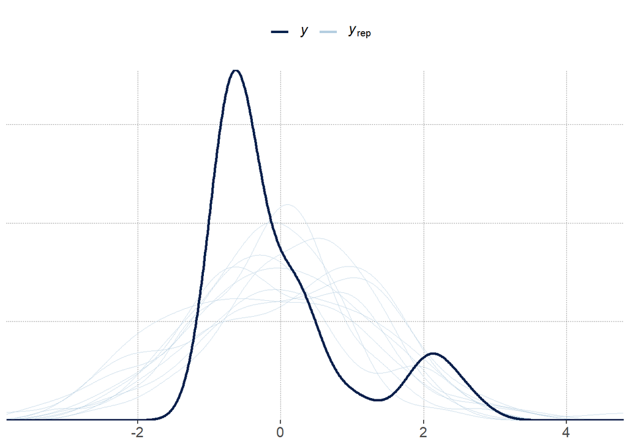

```r
#fit the model
pp_check(model_hypo1)
```

```r
# Extract the posteriors
posteriors1_trial_type <- model_hypo1 %>%
  spread_draws(b_Intercept,
               b_trial_typeTypical) %>%
  # calculate posteriors for each individual level
  mutate(Atypical = b_Intercept,
         Typical = b_Intercept + b_trial_typeTypical) %>%
  select(Atypical, Typical) %>%
  gather(key = "parameter", value = "posterior") %>%
  group_by(parameter) %>%
  summarise(mean_posterior = mean(posterior),
            `95lowerCrI` = HDInterval::hdi(posterior, credMass = 0.90)[1],
            `95higherCrI` = HDInterval::hdi(posterior, credMass = 0.90)[2])

posteriors1_trial_type
```

```
## # A tibble: 2 x 4
##   parameter mean_posterior `95lowerCrI` `95higherCrI`
##   <chr>              <dbl>        <dbl>         <dbl>
## 1 Atypical          0.287        -0.373         1.05
## 2 Typical          -0.0573       -0.684         0.533
```

```r
# Extract the posteriors
posteriors1 <- model_hypo1 %>%
  spread_draws(b_trial_typeTypical) %>%
  select(b_trial_typeTypical) %>%
  gather(key = "parameter", value = "posterior")


posteriors1
```

```
## # A tibble: 4,000 x 2
##    parameter           posterior
##    <chr>                   <dbl>
##  1 b_trial_typeTypical   -0.720
##  2 b_trial_typeTypical   -0.0900
##  3 b_trial_typeTypical   -0.548
##  4 b_trial_typeTypical   -0.964
##  5 b_trial_typeTypical    0.262
##  6 b_trial_typeTypical   -0.802
##  7 b_trial_typeTypical   -0.415
##  8 b_trial_typeTypical    0.315
##  9 b_trial_typeTypical   -0.591
## 10 b_trial_typeTypical   -0.652
## # ... with 3,990 more rows
```

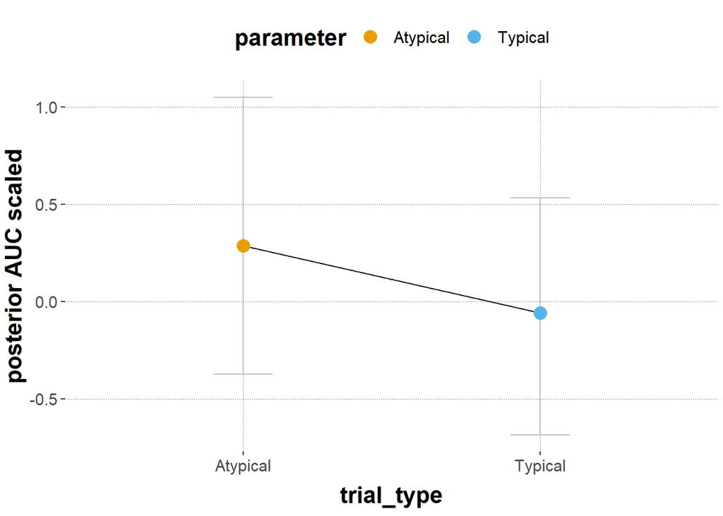

```r
# plot
ggplot(data = posteriors1_trial_type,
       aes(x = parameter, y = mean_posterior,
           color = parameter, fill = parameter)) +
  geom_errorbar(aes(ymin = `95lowerCrI`, ymax = `95higherCrI`),
                width = 0.2, color = "grey") +
  geom_line(aes(group = 1), color = "black") +
  geom_point(size = 4) +
  labs(x = "trial_type",
       y = "posterior AUC scaled")
```

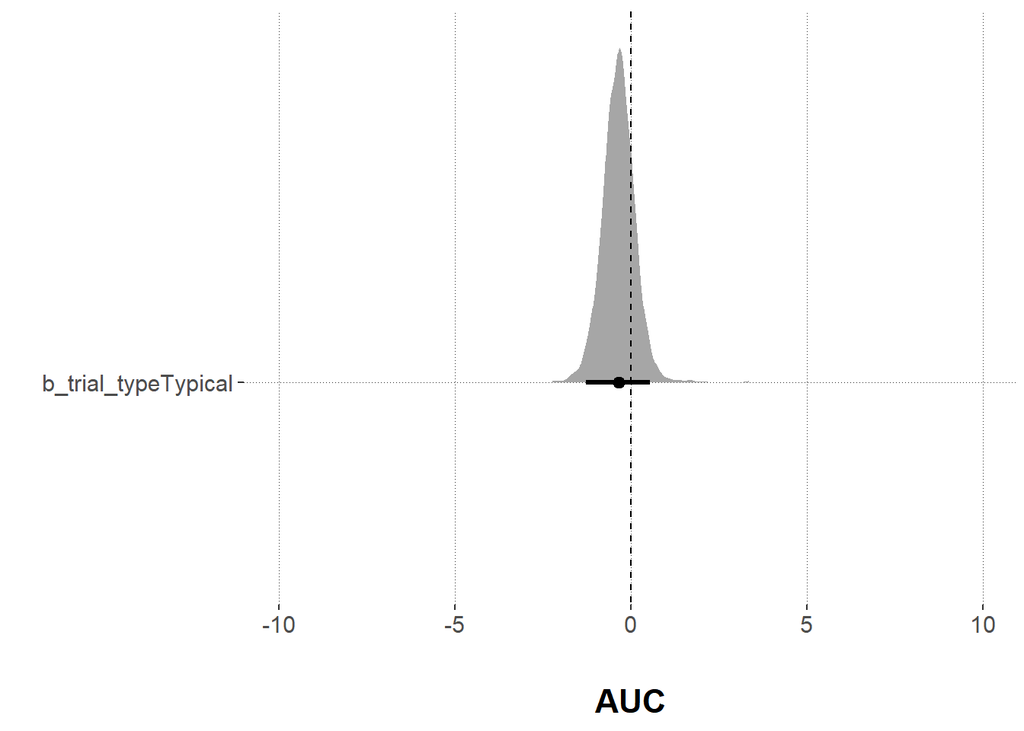

```r
# plot the regression coefficients
  ggplot(posteriors1, aes(x = posterior, y = parameter)) +
    # plot density
    geom_halfeyeh(.width = 0.95) +
    # add axes titles
    xlab("\nAUC") +
    ylab("") +
    # adjust the x-axis
    scale_x_continuous(limits = c(-10,10)) +
    # add line for the value zero
    geom_segment(x = 0, xend = 0, y = Inf, yend = -Inf,
                 lty = "dashed")
```

Results: AUC values are higher for Atypical than Typical trial types, due to the negative slope going from the reference level (Atypical) to the Typical trial type. The credible interval of the coefficient trial_typeTypical includes 0, wherefore there is no compelling evidence for the hypothesis to hold true.

Hypothesis 2

```r
#Taking absolute AUC values, since negative AUC make no sense
animal$MAD_abs = abs(animal$MAD)
animal$MAD_abs_s = my_scale(animal$MAD_abs)

#informative prior
prior_hypo2 <- c(
  #priors for all fixed effects (trial_type)
  set_prior("student_t(3, 0, 2.5)", class = "b"),
  #prior for the Intercept
  set_prior("student_t(3, -1, 2.5)", class = "Intercept"),
  #prior for all SDs including the varying intercepts and slopes
  set_prior("student_t(3, 0, 2.5)", class = "sd")
)

#by-subject_id varying intercepts and varying
#slope, without slope/intercept correlation
#by-exemplar varying intercept
model_hypo2 = brm(
  MAD_abs_s ~ trial_type +
    (trial_type || subject_id)+
    (1|exemplar),
  control=list(adapt_delta=0.99, max_treedepth=15),
  data = animal,
  prior = prior_hypo2
  )

#looking at model
model_hypo2
```

```
##  Family: gaussian
##   Links: mu = identity; sigma = identity
## Formula: MAD_abs_s ~ trial_type + (trial_type || subject_id) + (1 | exemplar)
##    Data: animal (Number of observations: 51)
## Samples: 4 chains, each with iter = 2000; warmup = 1000; thin = 1;
##          total post-warmup samples = 4000
##
## Group-Level Effects:
## ~exemplar (Number of levels: 15)
##               Estimate Est.Error l-95% CI u-95% CI Rhat Bulk_ESS Tail_ESS
## sd(Intercept)     0.33      0.23     0.02     0.86 1.01     1214     1819
##
## ~subject_id (Number of levels: 5)
##                       Estimate Est.Error l-95% CI u-95% CI Rhat Bulk_ESS
## sd(Intercept)             0.40      0.36     0.02     1.28 1.00     1267
## sd(trial_typeTypical)     0.34      0.34     0.01     1.24 1.00     1811
##                       Tail_ESS
## sd(Intercept)             2046
## sd(trial_typeTypical)     2017
##
## Population-Level Effects:
##                   Estimate Est.Error l-95% CI u-95% CI Rhat Bulk_ESS Tail_ESS
## Intercept             0.22      0.43    -0.64     1.06 1.00     3170     2572
## trial_typeTypical    -0.29      0.47    -1.24     0.62 1.00     2958     2274
##
## Family Specific Parameters:
##       Estimate Est.Error l-95% CI u-95% CI Rhat Bulk_ESS Tail_ESS
## sigma     0.98      0.11     0.79     1.22 1.00     2438     2633
##
## Samples were drawn using sampling(NUTS). For each parameter, Bulk_ESS
## and Tail_ESS are effective sample size measures, and Rhat is the potential
## scale reduction factor on split chains (at convergence, Rhat = 1).
```

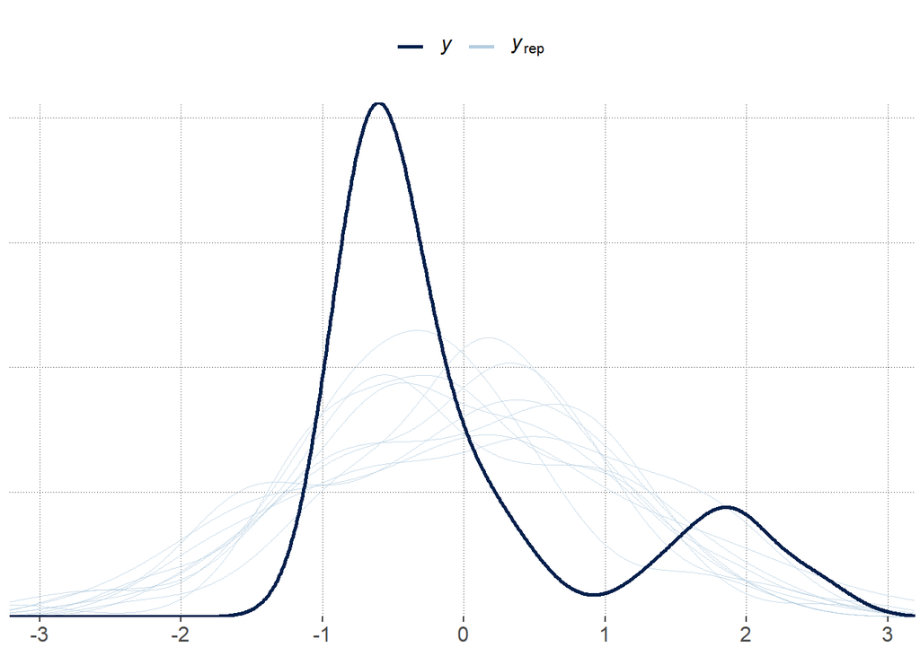

```r
#fitting model to actual data
pp_check(model_hypo2)
```

```r
# Extract the posteriors
posteriors2_trial_type <- model_hypo2 %>%
  spread_draws(b_Intercept,
               b_trial_typeTypical) %>%
  # calculate posteriors for each individual level
  mutate(Atypical = b_Intercept,
         Typical = b_Intercept + b_trial_typeTypical) %>%
  select(Atypical, Typical) %>%
  gather(key = "parameter", value = "posterior") %>%
  group_by(parameter) %>%
  summarise(mean_posterior = mean(posterior),
            `95lowerCrI` = HDInterval::hdi(posterior, credMass = 0.90)[1],
            `95higherCrI` = HDInterval::hdi(posterior, credMass = 0.90)[2])

posteriors2_trial_type
```

```
## # A tibble: 2 x 4
##   parameter mean_posterior `95lowerCrI` `95higherCrI`
##   <chr>              <dbl>        <dbl>         <dbl>
## 1 Atypical          0.216        -0.517         0.891
## 2 Typical          -0.0769       -0.640         0.518
```

```r
# Extract the posteriors
posteriors2 <- model_hypo2 %>%
  spread_draws(b_trial_typeTypical) %>%
  select(b_trial_typeTypical) %>%
  gather(key = "parameter", value = "posterior")


posteriors2
```

```
## # A tibble: 4,000 x 2
##    parameter           posterior
##    <chr>                   <dbl>
##  1 b_trial_typeTypical   -0.327
##  2 b_trial_typeTypical    0.0774
##  3 b_trial_typeTypical   -0.185
##  4 b_trial_typeTypical   -0.224
##  5 b_trial_typeTypical   -0.671
##  6 b_trial_typeTypical    0.121
##  7 b_trial_typeTypical    0.147
##  8 b_trial_typeTypical    0.479
##  9 b_trial_typeTypical    0.395
## 10 b_trial_typeTypical   -0.241
## # ... with 3,990 more rows
```

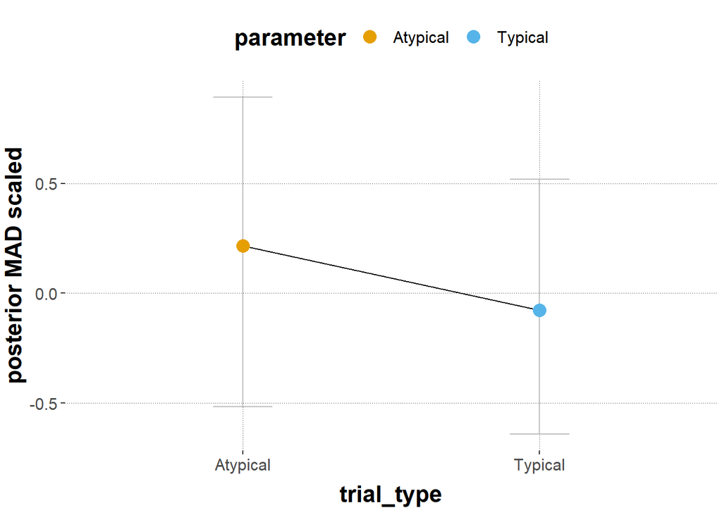

```r
# plot
ggplot(data = posteriors2_trial_type,
       aes(x = parameter, y = mean_posterior,
           color = parameter, fill = parameter)) +
  geom_errorbar(aes(ymin = `95lowerCrI`, ymax = `95higherCrI`),
                width = 0.2, color = "grey") +
  geom_line(aes(group = 1), color = "black") +
  geom_point(size = 4) +
  labs(x = "trial_type",
       y = "posterior MAD scaled")
```

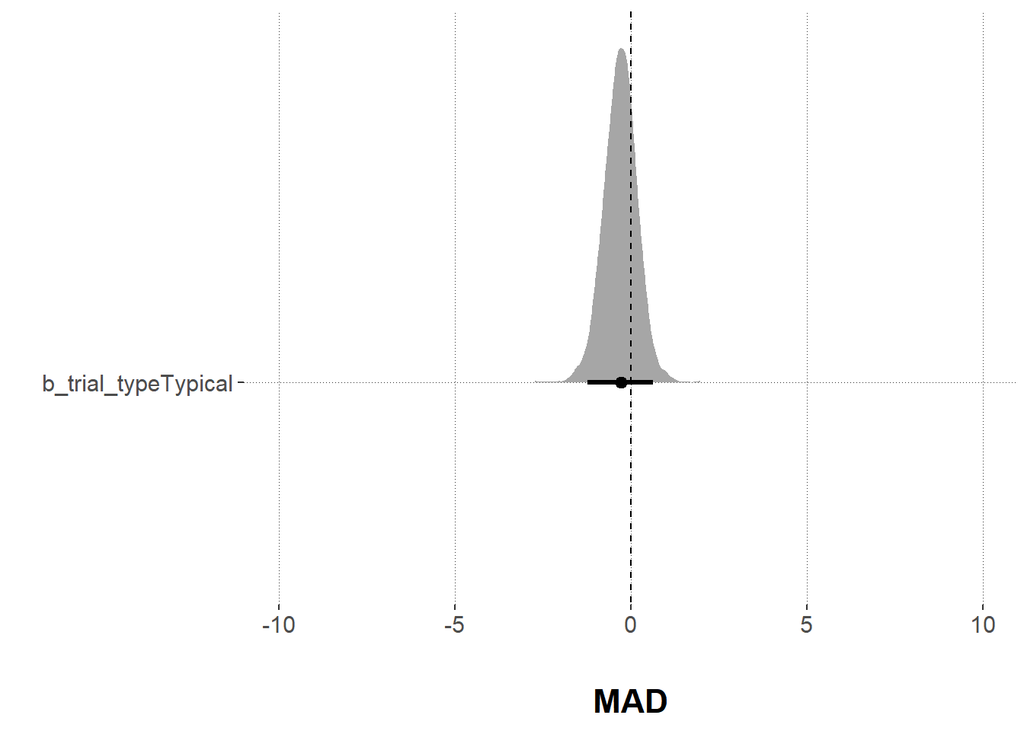

```r
# plot the regression coefficients
  ggplot(posteriors2, aes(x = posterior, y = parameter)) +
    # plot density
    geom_halfeyeh(.width = 0.95) +
    # add axes titles
    xlab("\nMAD") +
    ylab("") +
    # adjust the x-axis
    scale_x_continuous(limits = c(-10,10)) +
    # add line for the value zero
    geom_segment(x = 0, xend = 0, y = Inf, yend = -Inf,
                 lty = "dashed")
```

Results: MAD values are higher for Atypical than Typical trial types, due to the negative slope going from the reference level (Atypical) to the Typical trial type. The credible interval of the coefficient trial_typeTypical includes 0, wherefore there is no compelling evidence for the hypothesis to hold true.

Hypothesis 3

```r
animal$mousetrackingDuration_s = my_scale(animal$mousetrackingDuration)

#informative prior
prior_hypo3 <- c(
  #priors for all fixed effects (trial_type)
  set_prior("student_t(3, 0, 300)", class = "b"),
  #prior for the Intercept
  set_prior("student_t(3, 1000, 300)", class = "Intercept"),
  #prior for all SDs including the varying intercepts and slopes
  set_prior("student_t(3, 0, 300)", class = "sd")
)

#by-subject_id varying intercepts and varying
#slope, without slope/intercept correlation
#by-exemplar varying intercept
model_hypo3 = brm(
  mousetrackingDuration_s ~ trial_type +
    (trial_type || subject_id)+
    (1|exemplar),
  control=list(adapt_delta=0.99, max_treedepth=15),
  data = animal,
  prior = prior_hypo3
  )

model_hypo3
```

```
##  Family: gaussian
##   Links: mu = identity; sigma = identity
## Formula: mousetrackingDuration_s ~ trial_type + (trial_type || subject_id) + (1 | exemplar)
##    Data: animal (Number of observations: 51)
## Samples: 4 chains, each with iter = 2000; warmup = 1000; thin = 1;
##          total post-warmup samples = 4000
##
## Group-Level Effects:
## ~exemplar (Number of levels: 15)
##               Estimate Est.Error l-95% CI u-95% CI Rhat Bulk_ESS Tail_ESS
## sd(Intercept)     0.65      0.37     0.04     1.45 1.01      407      948
##
## ~subject_id (Number of levels: 5)
##                       Estimate Est.Error l-95% CI u-95% CI Rhat Bulk_ESS
## sd(Intercept)             0.75      0.62     0.09     2.25 1.00     1316
## sd(trial_typeTypical)     0.54      0.67     0.02     1.97 1.00     1308
##                       Tail_ESS
## sd(Intercept)             1978
## sd(trial_typeTypical)     1723
##
## Population-Level Effects:
##                   Estimate Est.Error l-95% CI u-95% CI Rhat Bulk_ESS Tail_ESS
## Intercept             0.58      0.64    -0.70     1.91 1.00     1844     1897
## trial_typeTypical    -0.71      0.61    -1.97     0.46 1.00     1911     1784
##
## Family Specific Parameters:
##       Estimate Est.Error l-95% CI u-95% CI Rhat Bulk_ESS Tail_ESS
## sigma     0.76      0.12     0.55     1.01 1.01      622     2053
##
## Samples were drawn using sampling(NUTS). For each parameter, Bulk_ESS
## and Tail_ESS are effective sample size measures, and Rhat is the potential
## scale reduction factor on split chains (at convergence, Rhat = 1).
```

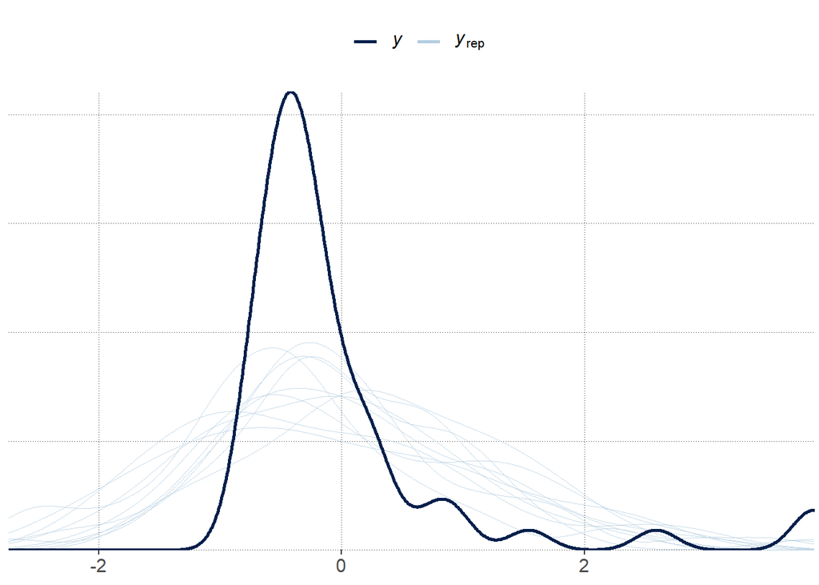

```r
#fitting the model to the actual data
pp_check(model_hypo3)
```

```r
# Extract the posteriors
posteriors3_trial_type <- model_hypo3 %>%
  spread_draws(b_Intercept,
               b_trial_typeTypical) %>%
  # calculate posteriors for each individual level
  mutate(Atypical = b_Intercept,
         Typical = b_Intercept + b_trial_typeTypical) %>%
  select(Atypical, Typical) %>%
  gather(key = "parameter", value = "posterior") %>%
  group_by(parameter) %>%
  summarise(mean_posterior = mean(posterior),
            `95lowerCrI` = HDInterval::hdi(posterior, credMass = 0.90)[1],
            `95higherCrI` = HDInterval::hdi(posterior, credMass = 0.90)[2])

posteriors3_trial_type
```

```
## # A tibble: 2 x 4
##   parameter mean_posterior `95lowerCrI` `95higherCrI`
##   <chr>              <dbl>        <dbl>         <dbl>
## 1 Atypical           0.581       -0.373         1.64
## 2 Typical           -0.126       -1.03          0.857
```

```r
# Extract the posteriors
posteriors3 <- model_hypo3 %>%
  spread_draws(b_trial_typeTypical) %>%
  select(b_trial_typeTypical) %>%
  gather(key = "parameter", value = "posterior")


posteriors3
```

```
## # A tibble: 4,000 x 2
##    parameter           posterior
##    <chr>                   <dbl>
##  1 b_trial_typeTypical   -0.763
##  2 b_trial_typeTypical   -1.03
##  3 b_trial_typeTypical   -0.124
##  4 b_trial_typeTypical   -0.908
##  5 b_trial_typeTypical   -0.936
##  6 b_trial_typeTypical   -0.613
##  7 b_trial_typeTypical   -1.16
##  8 b_trial_typeTypical   -0.0444
##  9 b_trial_typeTypical   -1.18
## 10 b_trial_typeTypical   -0.569
## # ... with 3,990 more rows
```

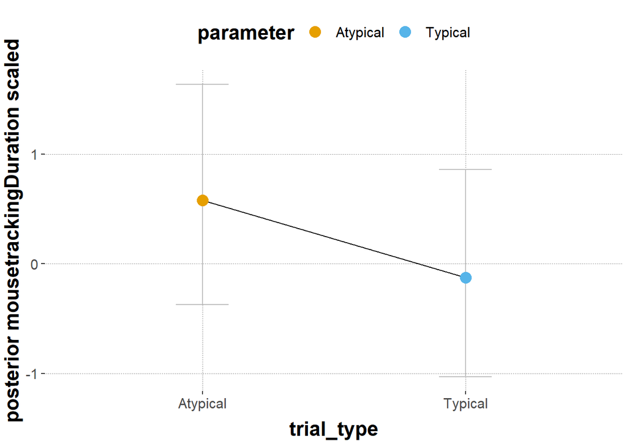

```r
# plot
ggplot(data = posteriors3_trial_type,
       aes(x = parameter, y = mean_posterior,
           color = parameter, fill = parameter)) +
  geom_errorbar(aes(ymin = `95lowerCrI`, ymax = `95higherCrI`),
                width = 0.2, color = "grey") +
  geom_line(aes(group = 1), color = "black") +
  geom_point(size = 4) +
  labs(x = "trial_type",
       y = "posterior mousetrackingDuration scaled")
```

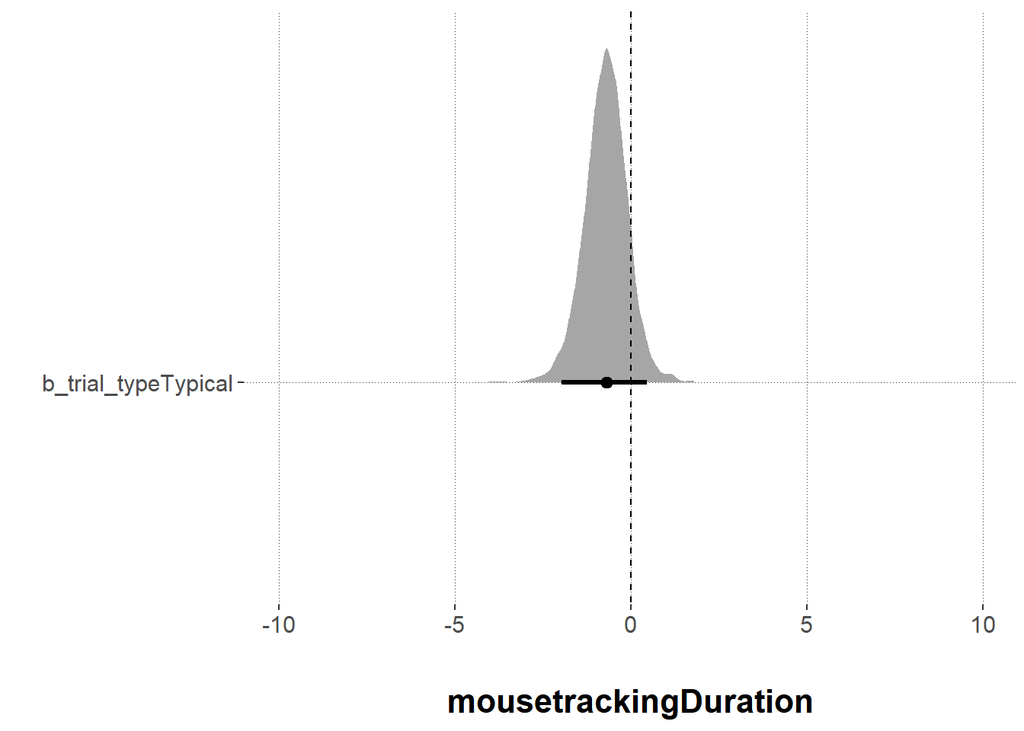

```r
# plot the regression coefficients
  ggplot(posteriors3, aes(x = posterior, y = parameter)) +
    # plot density
    geom_halfeyeh(.width = 0.95) +
    # add axes titles
    xlab("\nmousetrackingDuration") +
    ylab("") +
    # adjust the x-axis
    scale_x_continuous(limits = c(-10,10)) +
    # add line for the value zero
    geom_segment(x = 0, xend = 0, y = Inf, yend = -Inf,
                 lty = "dashed")
```

Results: The mousetracking duration values are higher for Atypical than Typical trial types, due to the negative slope going from the reference level (Atypical) to the Typical trial type. The credible interval of the coefficient trial_typeTypical includes 0, wherefore there is no compelling evidence for the hypothesis to hold true.

Hypothesis 4

```r
animal$factor_prototype_label <- factor(animal$prototype_label)

class(animal$factor_prototype_label)
```

```
## [1] "factor"
```

```r
#multinomial logistic regression model
#by-subject_id varying intercepts and varying
#slope, without slope/intercept correlation
#by-exemplar varying intercept
model_hypo4 <- brm(
  factor_prototype_label ~ trial_type +
    (trial_type || subject_id)+
    (1|exemplar),
  data = animal,
  family = categorical(link = "logit", refcat = NULL)
)

model_hypo4
```

```
##  Family: categorical
##   Links: mucurved = logit; mudCoM = logit; mustraight = logit
## Formula: factor_prototype_label ~ trial_type + (trial_type || subject_id) + (1 | exemplar)
##    Data: animal (Number of observations: 51)
## Samples: 4 chains, each with iter = 2000; warmup = 1000; thin = 1;
##          total post-warmup samples = 4000
##
## Group-Level Effects:
## ~exemplar (Number of levels: 15)
##                          Estimate Est.Error l-95% CI u-95% CI Rhat Bulk_ESS
## sd(mucurved_Intercept)       1.54      1.19     0.08     4.69 1.00     1543
## sd(mudCoM_Intercept)         1.62      1.32     0.07     5.02 1.00     1165
## sd(mustraight_Intercept)     0.77      0.62     0.03     2.32 1.00     1766
##                          Tail_ESS
## sd(mucurved_Intercept)       2168
## sd(mudCoM_Intercept)         2230
## sd(mustraight_Intercept)     2032
##
## ~subject_id (Number of levels: 5)
##                                  Estimate Est.Error l-95% CI u-95% CI Rhat
## sd(mucurved_Intercept)               1.78      1.37     0.08     5.20 1.00
## sd(mucurved_trial_typeTypical)       1.84      1.47     0.09     5.46 1.00
## sd(mudCoM_Intercept)                 2.05      1.62     0.11     6.12 1.00
## sd(mudCoM_trial_typeTypical)         2.14      1.85     0.07     6.77 1.00
## sd(mustraight_Intercept)             0.82      0.77     0.03     2.85 1.00
## sd(mustraight_trial_typeTypical)     0.90      0.85     0.03     3.21 1.00
##                                  Bulk_ESS Tail_ESS
## sd(mucurved_Intercept)               2213     1995
## sd(mucurved_trial_typeTypical)       2617     2611
## sd(mudCoM_Intercept)                 2145     1732
## sd(mudCoM_trial_typeTypical)         2653     2184
## sd(mustraight_Intercept)             3074     2760
## sd(mustraight_trial_typeTypical)     2599     2266
##
## Population-Level Effects:
##                              Estimate Est.Error l-95% CI u-95% CI Rhat Bulk_ESS
## mucurved_Intercept               5.46      6.13    -3.52    20.58 1.00     1280
## mudCoM_Intercept                 7.35      5.95    -0.67    22.27 1.00     1333
## mustraight_Intercept             8.79      5.95     1.35    23.52 1.00     1395
## mucurved_trial_typeTypical      -5.46      6.48   -21.39     3.84 1.00     1346
## mudCoM_trial_typeTypical        -9.06      6.66   -25.81    -0.06 1.00     1328
## mustraight_trial_typeTypical    -6.62      6.03   -21.28     1.03 1.00     1374
##                              Tail_ESS
## mucurved_Intercept                835
## mudCoM_Intercept                  882
## mustraight_Intercept              859
## mucurved_trial_typeTypical        924
## mudCoM_trial_typeTypical          926
## mustraight_trial_typeTypical      847
##
## Samples were drawn using sampling(NUTS). For each parameter, Bulk_ESS
## and Tail_ESS are effective sample size measures, and Rhat is the potential
## scale reduction factor on split chains (at convergence, Rhat = 1).
```

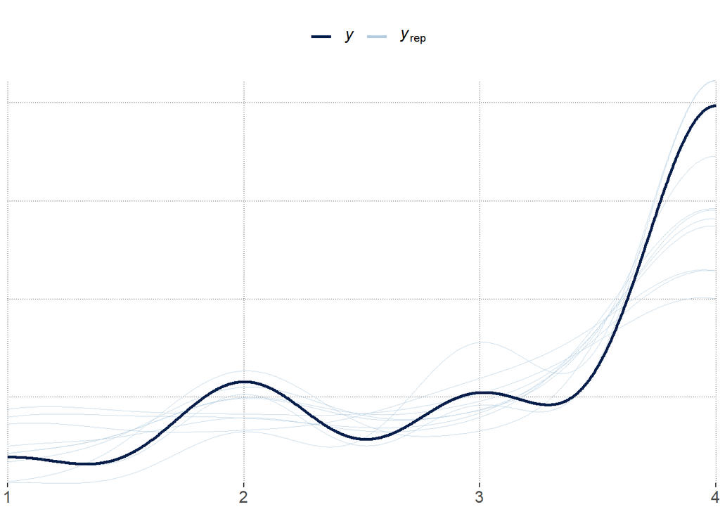

```r
#fitting the model to the actual data
pp_check(model_hypo4)
```

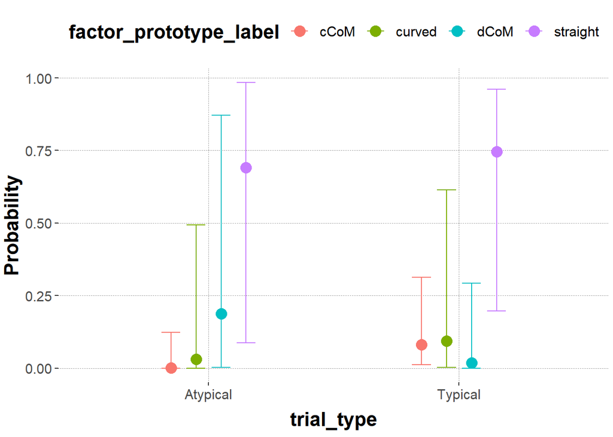

```r
marginal_effects(model_hypo4, "trial_type", categorical = TRUE)
```

```r
#extracting posteriors
predicted_hypo4 <- model_hypo4 %>%
  spread_draws(b_mucurved_Intercept,
               b_mudCoM_Intercept,
               b_mustraight_Intercept ,
               b_mucurved_trial_typeTypical,
               b_mudCoM_trial_typeTypical,
               b_mustraight_trial_typeTypical) %>%
  # mutating the parameters with their coefficient combination
  mutate(curved_Atypical = plogis(b_mucurved_Intercept),
         curved_Typical = plogis(b_mucurved_Intercept + b_mucurved_trial_typeTypical),
         dCoM_Atypical = plogis(b_mudCoM_Intercept),
          dCoM_Typical = plogis(b_mudCoM_Intercept + b_mudCoM_trial_typeTypical),
         straight_Atypical = plogis(b_mustraight_Intercept),
         straight_Typical = plogis(b_mustraight_Intercept + b_mustraight_trial_typeTypical),
         cCoM_Atypical = plogis(b_mucurved_Intercept + b_mudCoM_Intercept + b_mustraight_Intercept),
         cCoM_Typical = plogis(b_mucurved_Intercept + b_mudCoM_Intercept + b_mustraight_Intercept + b_mucurved_trial_typeTypical +
                             b_mudCoM_trial_typeTypical + b_mustraight_trial_typeTypical)) %>%
  select(curved_Atypical, curved_Typical, dCoM_Atypical, dCoM_Typical, straight_Atypical, straight_Typical, cCoM_Atypical, cCoM_Typical) %>%
  gather(key = "parameter", value = "posterior") %>%
  #muatating categories for cluster and condition for better plotting
   mutate(prototype = ifelse(parameter == "curved_Atypical" | parameter == "curved_Typical",
                        "curved",ifelse(parameter == "dCoM_Atypical"|parameter == "dCoM_Typical", "dcom", ifelse(parameter == "straight_Atypical"|parameter == "straight_Typical", "straight", "cCoM"))),
          trial_type = ifelse(parameter == "curved_Atypical" | parameter == "dCoM_Atypical" | parameter == "straight_Atypical" | parameter == "cCoM_Atypical",
                        "Atypical", "Typical")) %>%
  group_by(prototype, trial_type) %>%
  summarise(mean_posterior = mean(posterior),
            `95lowerCrI` = HDInterval::hdi(posterior, credMass = 0.90)[1],
            `95higherCrI` = HDInterval::hdi(posterior, credMass = 0.90)[2])

predicted_hypo4
```

```
## # A tibble: 8 x 5
## # Groups:   prototype [4]
##   prototype trial_type mean_posterior `95lowerCrI` `95higherCrI`
##   <chr>     <chr>               <dbl>        <dbl>         <dbl>
## 1 cCoM      Atypical            0.963  0.979               1
## 2 cCoM      Typical             0.561  0.0315              1.00
## 3 curved    Atypical            0.823  0.262               1
## 4 curved    Typical             0.509  0.0757              0.923
## 5 dcom      Atypical            0.928  0.765               1
## 6 dcom      Typical             0.256  0.000000475         0.628
## 7 straight  Atypical            0.978  0.940               1
## 8 straight  Typical             0.863  0.721               0.997
```

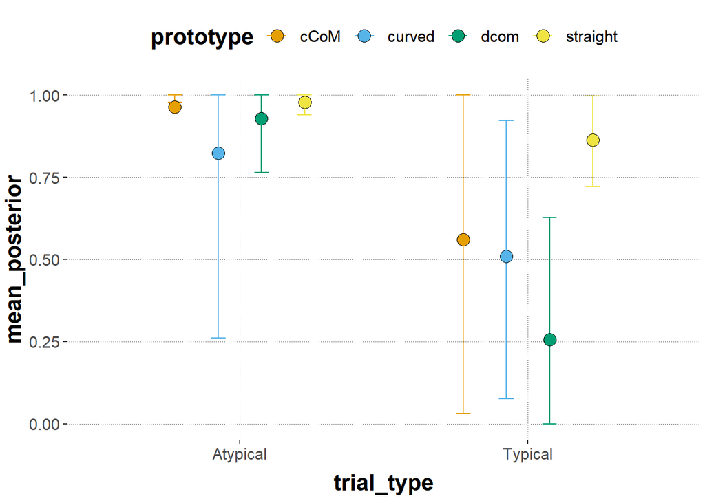

```r
#plotting mean posterior probability of every prototype for each trial type
ggplot(predicted_hypo4) +
   geom_errorbar(aes(x = trial_type, y = mean_posterior, color = prototype,
                    ymin = `95lowerCrI`, ymax = `95higherCrI`),
                width = 0.2,  position = position_dodge(width = 0.6)) +
  geom_point(aes(x = trial_type, y = mean_posterior, fill = prototype),
             size = 4, pch = 21, color = "black", position = position_dodge(0.6))
```

Results: The graph indicates that the mean posterior probabilities of the prototypes are higher for the Atypical trial compared to all mean posterior probabilities of the prototypes for the Typical trial type. Therefore we can assume that the likelihood of obtaining different cluster types depends on the experimental condition.

Hypothese 5

```r
animal$RT_log <- log(animal$RT)
animal$RT_log_s = my_scale(animal$RT_log)

#informative priors
prior_hypo5 <- c(
  #priors for all fixed effects (trial_type)
  set_prior("student_t(3, 7, 2.5)", class = "b"),
  #prior for the Intercept
  set_prior("student_t(3, 0, 2)", class = "Intercept"),
  #prior for all SDs including the varying intercepts and slopes
  set_prior("student_t(3, 0, 2)", class = "sd")
)

#by-subject_id varying intercepts and varying
#slope, without slope/intercept correlation
#by-exemplar varying intercept
model_hypo5 = brm(
  RT_log_s ~ trial_type +
    (trial_type || subject_id)+
    (1 |exemplar),
  control=list(adapt_delta=0.99, max_treedepth=15),
  data = animal,
  prior = prior_hypo5
  )


model_hypo5
```

```
##  Family: gaussian
##   Links: mu = identity; sigma = identity
## Formula: RT_log_s ~ trial_type + (trial_type || subject_id) + (1 | exemplar)
##    Data: animal (Number of observations: 51)
## Samples: 4 chains, each with iter = 2000; warmup = 1000; thin = 1;
##          total post-warmup samples = 4000
##
## Group-Level Effects:
## ~exemplar (Number of levels: 15)
##               Estimate Est.Error l-95% CI u-95% CI Rhat Bulk_ESS Tail_ESS
## sd(Intercept)     0.63      0.29     0.09     1.25 1.00      481      959
##
## ~subject_id (Number of levels: 5)
##                       Estimate Est.Error l-95% CI u-95% CI Rhat Bulk_ESS
## sd(Intercept)             0.86      0.47     0.27     1.99 1.00     1276
## sd(trial_typeTypical)     0.38      0.39     0.01     1.35 1.00     1227
##                       Tail_ESS
## sd(Intercept)             1418
## sd(trial_typeTypical)     1995
##
## Population-Level Effects:
##                   Estimate Est.Error l-95% CI u-95% CI Rhat Bulk_ESS Tail_ESS
## Intercept             0.64      0.57    -0.49     1.81 1.00     1880     2229
## trial_typeTypical    -0.77      0.53    -1.81     0.30 1.00     1666     1932
##
## Family Specific Parameters:
##       Estimate Est.Error l-95% CI u-95% CI Rhat Bulk_ESS Tail_ESS
## sigma     0.63      0.10     0.47     0.85 1.00      718     1424
##
## Samples were drawn using sampling(NUTS). For each parameter, Bulk_ESS
## and Tail_ESS are effective sample size measures, and Rhat is the potential
## scale reduction factor on split chains (at convergence, Rhat = 1).
```

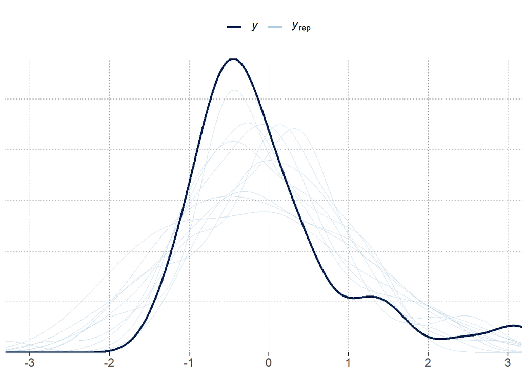

```r
#fitting the model to the actual data
pp_check(model_hypo5)
```

```r
# Extract the posteriors
posteriors5_trial_type <- model_hypo5 %>%
  spread_draws(b_Intercept,
               b_trial_typeTypical) %>%
  # calculate posteriors for each individual level
  mutate(Atypical = b_Intercept,
         Typical = b_Intercept + b_trial_typeTypical) %>%
  select(Atypical, Typical) %>%
  gather(key = "parameter", value = "posterior") %>%
  group_by(parameter) %>%
  summarise(mean_posterior = mean(posterior),
            `95lowerCrI` = HDInterval::hdi(posterior, credMass = 0.90)[1],
            `95higherCrI` = HDInterval::hdi(posterior, credMass = 0.90)[2])

posteriors5_trial_type
```

```
## # A tibble: 2 x 4
##   parameter mean_posterior `95lowerCrI` `95higherCrI`
##   <chr>              <dbl>        <dbl>         <dbl>
## 1 Atypical           0.641       -0.306         1.56
## 2 Typical           -0.129       -0.970         0.750
```

```r
# Extract the posteriors
posteriors5 <- model_hypo5 %>%
  spread_draws(b_trial_typeTypical) %>%
  select(b_trial_typeTypical) %>%
  gather(key = "parameter", value = "posterior")


posteriors5
```

```
## # A tibble: 4,000 x 2
##    parameter           posterior
##    <chr>                   <dbl>
##  1 b_trial_typeTypical    -0.958
##  2 b_trial_typeTypical    -0.251
##  3 b_trial_typeTypical    -1.33
##  4 b_trial_typeTypical    -0.843
##  5 b_trial_typeTypical    -1.56
##  6 b_trial_typeTypical    -0.540
##  7 b_trial_typeTypical    -0.557
##  8 b_trial_typeTypical    -1.43
##  9 b_trial_typeTypical    -0.903
## 10 b_trial_typeTypical    -1.47
## # ... with 3,990 more rows
```

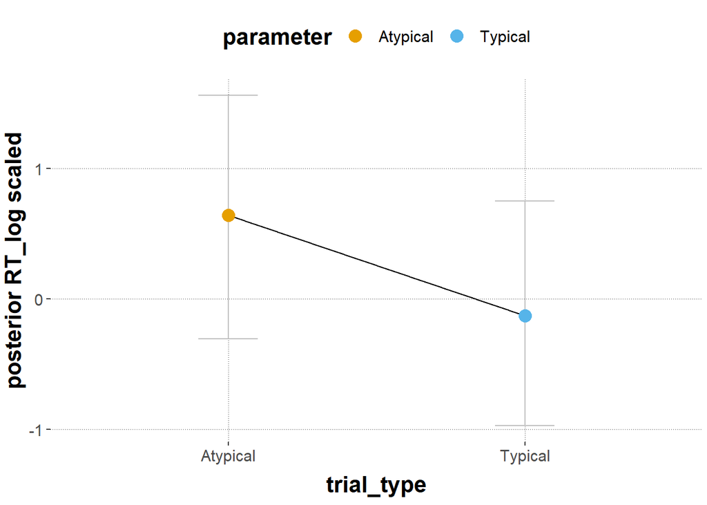

```r
# plot
ggplot(data = posteriors5_trial_type,
       aes(x = parameter, y = mean_posterior,
           color = parameter, fill = parameter)) +
  geom_errorbar(aes(ymin = `95lowerCrI`, ymax = `95higherCrI`),
                width = 0.2, color = "grey") +
  geom_line(aes(group = 1), color = "black") +
  geom_point(size = 4) +
  labs(x = "trial_type",
       y = "posterior RT_log scaled")
```

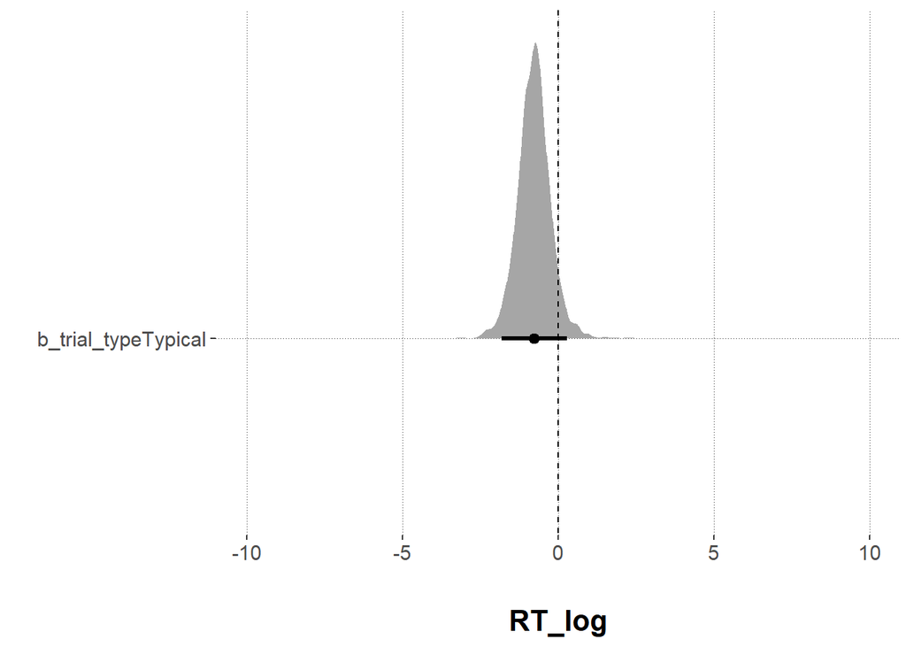

```r
# plot the regression coefficients
  ggplot(posteriors5, aes(x = posterior, y = parameter)) +
    # plot density
    geom_halfeyeh(.width = 0.95) +
    # add axes titles
    xlab("\nRT_log") +
    ylab("") +
    # adjust the x-axis
    scale_x_continuous(limits = c(-10,10)) +
    # add line for the value zero
    geom_segment(x = 0, xend = 0, y = Inf, yend = -Inf,
                 lty = "dashed")
```

Results: The scales RT_log values are higher for Atypical than Typical trial types, due to the negative slope going from the reference level (Atypical) to the Typical trial type. The credible interval of the coefficient trial_typeTypical includes 0, wherefore there is no compelling evidence for the hypothesis to hold true.

Hypothesis 6

```r
#informative prior
prior_hypo6 <- c(
  #priors for all fixed effects (trial_type)
  set_prior("student_t(3, 300, 400)", class = "b"),
  #prior for the Intercept
  set_prior("student_t(3, 0,400)", class = "Intercept"),
  #prior for all SDs including the varying intercepts and slopes
  set_prior("student_t(3, 0, 400)", class = "sd"),
  set_prior("student_t(3, 0, 400)", class = "sigma")
)

#by-subject_id varying intercepts and varying
#slope, without slope/intercept correlation
#by-exemplar varying intercept
model_hypo6 = brm(
  initiation_time ~ trial_type +
    (trial_type || subject_id)+
    (1 |exemplar),
  control=list(adapt_delta=0.99, max_treedepth=15),
  data = animal,
  prior = prior_hypo6
  )


model_hypo6
```

```
##  Family: gaussian
##   Links: mu = identity; sigma = identity
## Formula: initiation_time ~ trial_type + (trial_type || subject_id) + (1 | exemplar)
##    Data: animal (Number of observations: 51)
## Samples: 4 chains, each with iter = 2000; warmup = 1000; thin = 1;
##          total post-warmup samples = 4000
##
## Group-Level Effects:
## ~exemplar (Number of levels: 15)
##               Estimate Est.Error l-95% CI u-95% CI Rhat Bulk_ESS Tail_ESS
## sd(Intercept)   182.77    126.11     9.43   470.68 1.00     1355     1455
##
## ~subject_id (Number of levels: 5)
##                       Estimate Est.Error l-95% CI u-95% CI Rhat Bulk_ESS
## sd(Intercept)           296.70    199.40    18.46   755.30 1.00     1360
## sd(trial_typeTypical)   233.93    181.06     7.71   675.49 1.00     1614
##                       Tail_ESS
## sd(Intercept)             1459
## sd(trial_typeTypical)     1532
##
## Population-Level Effects:
##                   Estimate Est.Error l-95% CI u-95% CI Rhat Bulk_ESS Tail_ESS
## Intercept           333.05    270.81  -225.74   848.72 1.00     2777     2588
## trial_typeTypical    51.77    255.95  -469.65   537.68 1.00     3113     2420
##
## Family Specific Parameters:
##       Estimate Est.Error l-95% CI u-95% CI Rhat Bulk_ESS Tail_ESS
## sigma   682.03     76.65   550.14   848.22 1.00     3508     2986
##
## Samples were drawn using sampling(NUTS). For each parameter, Bulk_ESS
## and Tail_ESS are effective sample size measures, and Rhat is the potential
## scale reduction factor on split chains (at convergence, Rhat = 1).
```

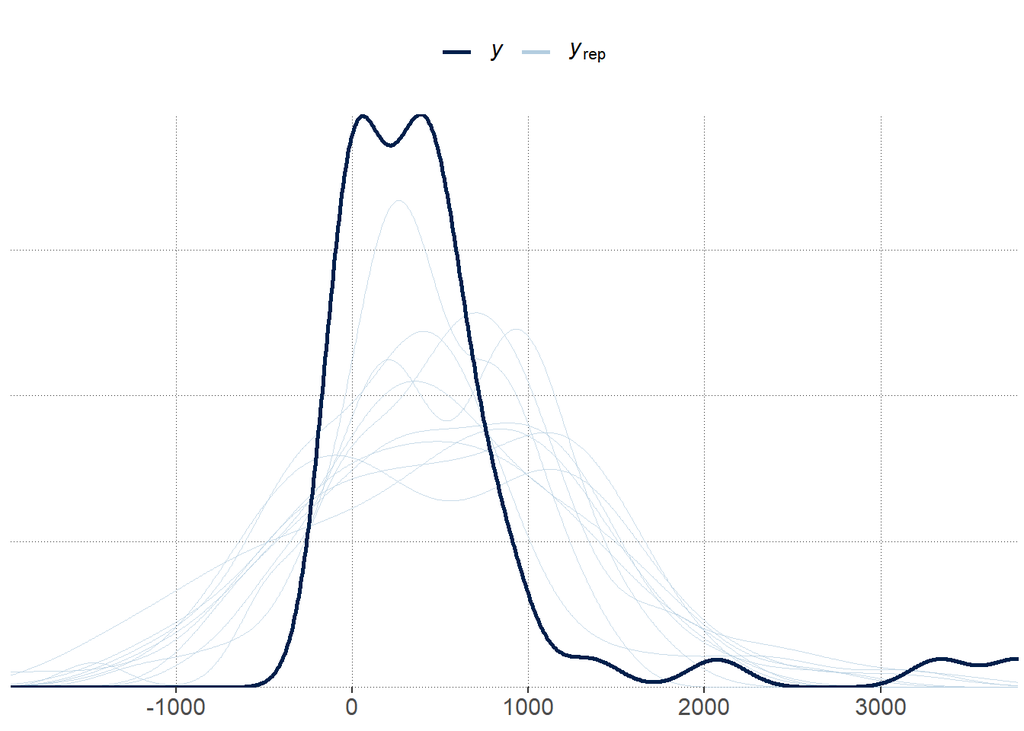

```r
#fitting the model to the actual data
pp_check(model_hypo6)
```

```r
# Extract the posteriors
posteriors6_trial_type <- model_hypo6 %>%
  spread_draws(b_Intercept,
               b_trial_typeTypical) %>%
  # calculate posteriors for each individual level
  mutate(Atypical = b_Intercept,
         Typical = b_Intercept + b_trial_typeTypical) %>%
  select(Atypical, Typical) %>%
  gather(key = "parameter", value = "posterior") %>%
  group_by(parameter) %>%
  summarise(mean_posterior = mean(posterior),
            `95lowerCrI` = HDInterval::hdi(posterior, credMass = 0.90)[1],
            `95higherCrI` = HDInterval::hdi(posterior, credMass = 0.90)[2])

posteriors6_trial_type
```

```
## # A tibble: 2 x 4
##   parameter mean_posterior `95lowerCrI` `95higherCrI`
##   <chr>              <dbl>        <dbl>         <dbl>
## 1 Atypical            333.       -126.           769.
## 2 Typical             385.         35.5          725.
```

```r
# Extract the posteriors
posteriors6 <- model_hypo6 %>%
  spread_draws(b_trial_typeTypical) %>%
  select(b_trial_typeTypical) %>%
  gather(key = "parameter", value = "posterior")


posteriors6
```

```
## # A tibble: 4,000 x 2
##    parameter           posterior
##    <chr>                   <dbl>
##  1 b_trial_typeTypical     -17.1
##  2 b_trial_typeTypical     -29.1
##  3 b_trial_typeTypical    -212.
##  4 b_trial_typeTypical      12.9
##  5 b_trial_typeTypical    -157.
##  6 b_trial_typeTypical     582.
##  7 b_trial_typeTypical    -253.
##  8 b_trial_typeTypical      71.4
##  9 b_trial_typeTypical     -95.2
## 10 b_trial_typeTypical    -220.
## # ... with 3,990 more rows
```

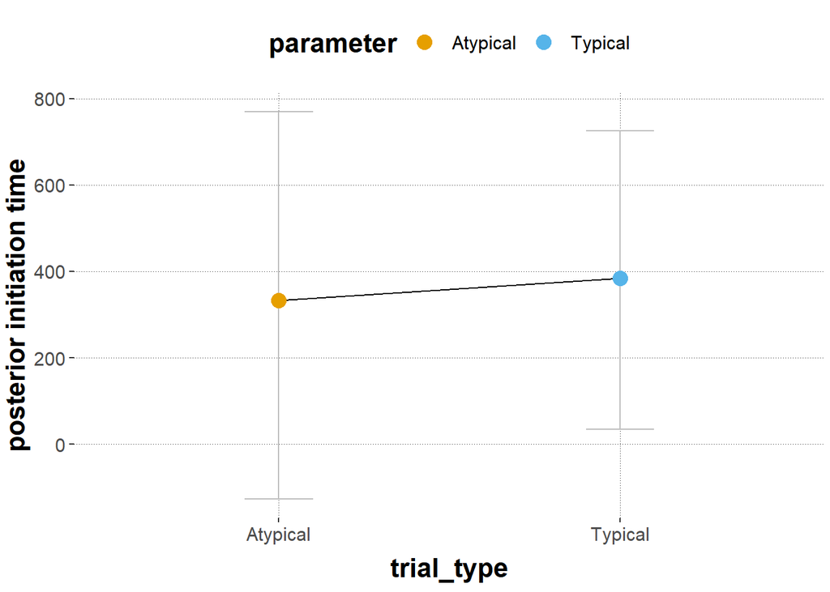

```r
# plot
ggplot(data = posteriors6_trial_type,
       aes(x = parameter, y = mean_posterior,
           color = parameter, fill = parameter)) +
  geom_errorbar(aes(ymin = `95lowerCrI`, ymax = `95higherCrI`),
                width = 0.2, color = "grey") +
  geom_line(aes(group = 1), color = "black") +
  geom_point(size = 4) +
  labs(x = "trial_type",
       y = "posterior initiation time")
```

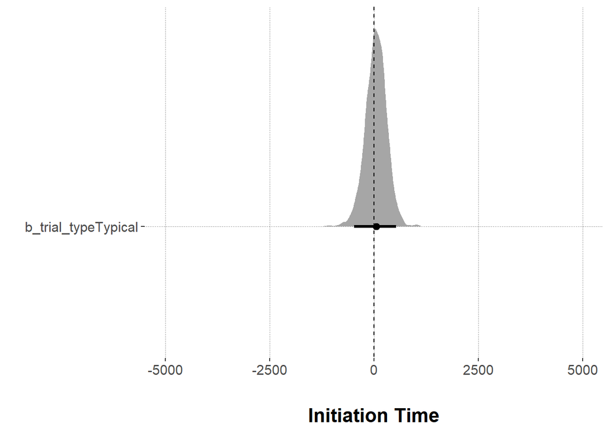

```r
# plot the regression coefficients
  ggplot(posteriors6, aes(x = posterior, y = parameter)) +
    # plot density
    geom_halfeyeh(.width = 0.95) +
    # add axes titles
    xlab("\nInitiation Time") +
    ylab("") +
    # adjust the x-axis
    scale_x_continuous(limits = c(-5000,5000)) +
    # add line for the value zero
    geom_segment(x = 0, xend = 0, y = Inf, yend = -Inf,
                 lty = "dashed")
```

Results: The initiation time values are lower for Atypical than Typical trial types, due to the positive slope going from the reference level (Atypical) to the Typical trial type. The credible interval of the coefficient trial_typeTypical includes 0, wherefore there is no compelling evidence for the hypothesis to hold true.

Hypothese 7

```r
animal$traveledDistance_abs <- abs(animal$traveledDistance)

#informative prior
prior_hypo7 <- c(
  #prior for the Intercept
  set_prior("student_t(3, 50,10)", class = "Intercept"),
  #prior for all SDs including the varying intercepts and slopes
  set_prior("student_t(3, 0, 10)", class = "sd"),
  set_prior("student_t(3, 0, 10)", class = "sigma")
)

#by-subject_id varying intercepts and varying
#slope, without slope/intercept correlation
#by-exemplar varying intercept
model_hypo7 = brm(
  traveledDistance_abs ~ trial_type +
    (trial_type || subject_id)+
    (1 |exemplar),
  control=list(adapt_delta=0.99, max_treedepth=15),
  data = animal,
  prior = prior_hypo7
  )


model_hypo7
```

```
##  Family: gaussian
##   Links: mu = identity; sigma = identity
## Formula: traveledDistance_abs ~ trial_type + (trial_type || subject_id) + (1 | exemplar)
##    Data: animal (Number of observations: 51)
## Samples: 4 chains, each with iter = 2000; warmup = 1000; thin = 1;
##          total post-warmup samples = 4000
##
## Group-Level Effects:
## ~exemplar (Number of levels: 15)
##               Estimate Est.Error l-95% CI u-95% CI Rhat Bulk_ESS Tail_ESS
## sd(Intercept)    13.49      7.89     1.06    29.75 1.00      390     1318
##
## ~subject_id (Number of levels: 5)
##                       Estimate Est.Error l-95% CI u-95% CI Rhat Bulk_ESS
## sd(Intercept)             8.44      5.23     0.67    19.82 1.00      909
## sd(trial_typeTypical)     5.73      4.77     0.25    17.64 1.00     1945
##                       Tail_ESS
## sd(Intercept)             1257
## sd(trial_typeTypical)     2123
##
## Population-Level Effects:
##                   Estimate Est.Error l-95% CI u-95% CI Rhat Bulk_ESS Tail_ESS
## Intercept            74.32     10.68    54.61    97.07 1.00     1906     1507
## trial_typeTypical   -26.43     12.38   -52.30    -3.03 1.00     1696     1322
##
## Family Specific Parameters:
##       Estimate Est.Error l-95% CI u-95% CI Rhat Bulk_ESS Tail_ESS
## sigma    19.54      3.21    13.95    26.05 1.00      482     1593
##
## Samples were drawn using sampling(NUTS). For each parameter, Bulk_ESS
## and Tail_ESS are effective sample size measures, and Rhat is the potential
## scale reduction factor on split chains (at convergence, Rhat = 1).
```

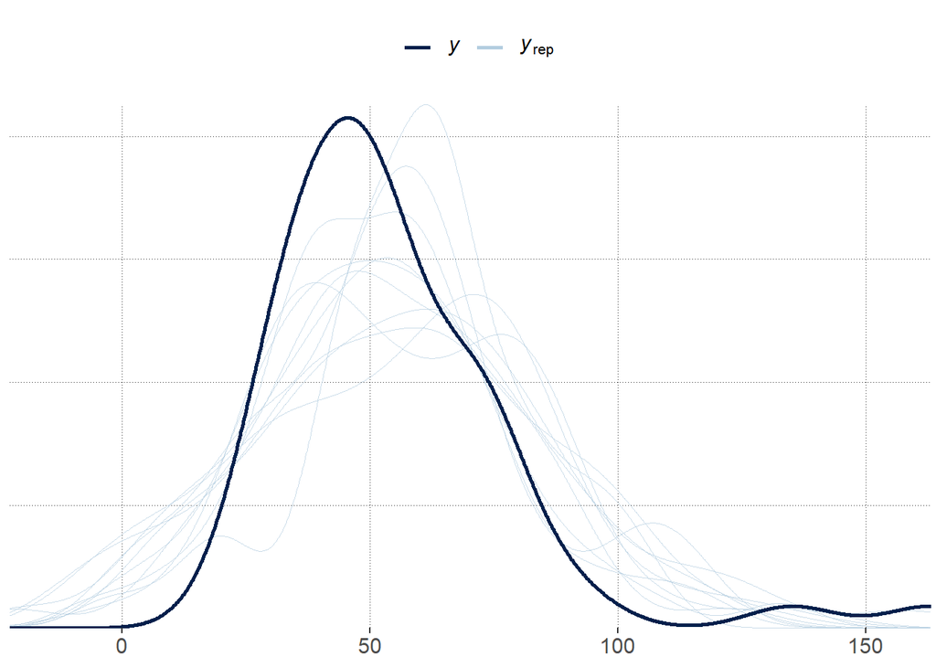

```r
#fitting the model to the actual data
pp_check(model_hypo7)
```

```r
# Extract the posteriors
posteriors7_trial_type <- model_hypo7 %>%
  spread_draws(b_Intercept,
               b_trial_typeTypical) %>%
  # calculate posteriors for each individual level
  mutate(Atypical = b_Intercept,
         Typical = b_Intercept + b_trial_typeTypical) %>%
  select(Atypical, Typical) %>%
  gather(key = "parameter", value = "posterior") %>%
  group_by(parameter) %>%
  summarise(mean_posterior = mean(posterior),
            `95lowerCrI` = HDInterval::hdi(posterior, credMass = 0.90)[1],
            `95higherCrI` = HDInterval::hdi(posterior, credMass = 0.90)[2])

posteriors7_trial_type
```

```
## # A tibble: 2 x 4
##   parameter mean_posterior `95lowerCrI` `95higherCrI`
##   <chr>              <dbl>        <dbl>         <dbl>
## 1 Atypical            74.3         55.9          89.9
## 2 Typical             47.9         36.2          57.8
```

```r
# Extract the posteriors
posteriors7 <- model_hypo7 %>%
  spread_draws(b_trial_typeTypical) %>%
  select(b_trial_typeTypical) %>%
  gather(key = "parameter", value = "posterior")


posteriors7
```

```
## # A tibble: 4,000 x 2
##    parameter           posterior
##    <chr>                   <dbl>
##  1 b_trial_typeTypical    -23.1
##  2 b_trial_typeTypical     -8.53
##  3 b_trial_typeTypical    -14.6
##  4 b_trial_typeTypical    -12.9
##  5 b_trial_typeTypical    -34.4
##  6 b_trial_typeTypical    -35.5
##  7 b_trial_typeTypical    -61.7
##  8 b_trial_typeTypical    -43.8
##  9 b_trial_typeTypical    -44.6
## 10 b_trial_typeTypical    -17.0
## # ... with 3,990 more rows
```

```r
posterior7_agg <- posteriors7 %>%
  mutate(mean_posterior = mean(posterior))

posterior7_agg
```

```
## # A tibble: 4,000 x 3
##    parameter           posterior mean_posterior
##    <chr>                   <dbl>          <dbl>
##  1 b_trial_typeTypical    -23.1           -26.4
##  2 b_trial_typeTypical     -8.53          -26.4
##  3 b_trial_typeTypical    -14.6           -26.4
##  4 b_trial_typeTypical    -12.9           -26.4
##  5 b_trial_typeTypical    -34.4           -26.4
##  6 b_trial_typeTypical    -35.5           -26.4
##  7 b_trial_typeTypical    -61.7           -26.4
##  8 b_trial_typeTypical    -43.8           -26.4
##  9 b_trial_typeTypical    -44.6           -26.4
## 10 b_trial_typeTypical    -17.0           -26.4
## # ... with 3,990 more rows
```

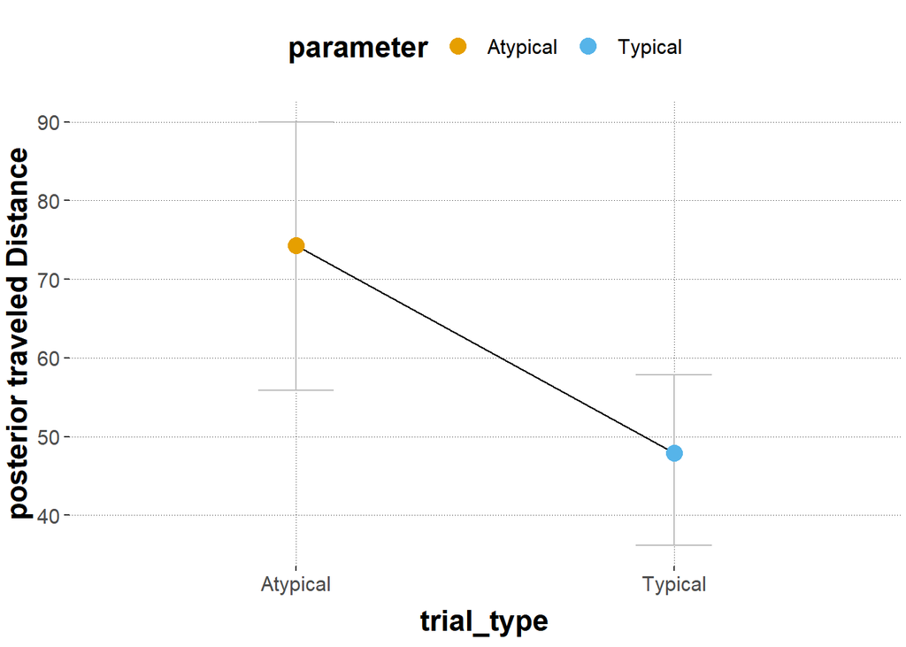

```r
# plot
ggplot(data = posteriors7_trial_type,
       aes(x = parameter, y = mean_posterior,
           color = parameter, fill = parameter)) +
  geom_errorbar(aes(ymin = `95lowerCrI`, ymax = `95higherCrI`),
                width = 0.2, color = "grey") +
  geom_line(aes(group = 1), color = "black") +
  geom_point(size = 4) +
  labs(x = "trial_type",
       y = "posterior traveled Distance")
```

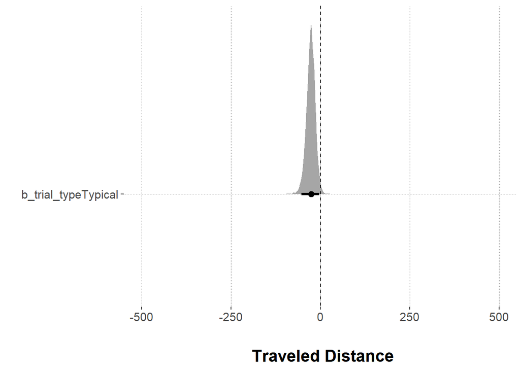

```r
# plot the regression coefficients
  ggplot(posteriors7, aes(x = posterior, y = parameter)) +
    # plot density
    geom_halfeyeh(.width = 0.95) +
    # add axes titles
    xlab("\n Traveled Distance") +
    ylab("") +
    # adjust the x-axis
    scale_x_continuous(limits = c(-500,500)) +
    # add line for the value zero
    geom_segment(x = 0, xend = 0, y = Inf, yend = -Inf,
                 lty = "dashed")
```

```r
#computing evidential ratio and posterior probability
hypothesis(model_hypo7, "trial_typeTypical > -25.60")
```

```
## Hypothesis Tests for class b:
##                 Hypothesis Estimate Est.Error CI.Lower CI.Upper Evid.Ratio
## 1 (trial_typeTypica... > 0    -0.83     12.38   -21.75    18.49       0.95
##   Post.Prob Star
## 1      0.49
## ---
## 'CI': 90%-CI for one-sided and 95%-CI for two-sided hypotheses.
## '*': For one-sided hypotheses, the posterior probability exceeds 95%;
## for two-sided hypotheses, the value tested against lies outside the 95%-CI.
## Posterior probabilities of point hypotheses assume equal prior probabilities.
```